# Stat 113 Section 1 - Fall 2024

# *8/29: INTRODUCTION*

## Contact Information

- Stat 113 - Section 1
- Room: HN 305 (In Person)
- Schedule: Monday and Thursday (8:30am - 9:45am)
- **Instructor:** Alejandro Falchettore
- **email:** afalche@hunter.cuny.edu)
- **Office Hours (ZOOM - By appointment):** Monday: 1:00 - 2:00 pm

## ALEKS Registration

- Access ALEKS: https://www.aleks.com
- Click on **SIGN UP**.
- ALEKS Class Code (For Registration Only): **Q6KUG-HAAMK**
- TEMPORARY Financial Aid Access Code (two-week trial): *Contact your instructor*
- The Financial Aid Access Code gives you **temporary access** to ALEKS for a two-week period. Once the code expires, you will be locked out of your ALEKS account until you purchase a regular Student Access Code. It is highly recommended that you purchase the Student Access Code BEFORE the two weeks expire to prevent interruptions with your ALEKS account. The Financial Aid Access Code does not add an additional two weeks to your account.
- **DO NOT FORGET** your username and password.

**IMPORTANT:** Complete the Initial Knowledge Check **TODAY**.

# *9/5 : THE STATISTICAL SOFTWARE*

**R STUDIO** *(In the lab, Room 305HN)*

- Click on the WINDOW icon. Search and click *R STUDIO*.
- The statistical software is required for Data Day and Independent projects **ONLY**.
- Knowledge of the statistical software is **NOT** part of midterms and final exam.

**AT HOME**, you can choose one of the two options:

*1)* Install R STUDIO, **free version**, in your laptop (or home computer): https://posit.co/downloads/

- Read the instructions carefully. If you need help, request a ZOOM meeting with me.

*2)* Work in the cloud, no installation is required. Sign-in with your Google account: https://posit.cloud/

### Basic Exploration of R Studio

In the **CONSOLE**, left panel, type the following expressions and press ENTER.

- 2 + 3
- 2 + 3 * 5
- (2 + 3) * 5
- log(5)
- 6^2
- exp(3)
- sin(pi/2)

Clear the **console** by pressing **CTRL** + **L**.

### Working with Scripts

- Click on FILE > NEW FILE > R SCRIPT
- The R script is a *text editor* located above the CONSOLE panel.
- In R script, you are going to run codes of your data analysis. You can also edit, comment and save them.
- In general, you select the codes to run. If the code is in a single line, it is enough placing the cursor in that line. Then click on the *RUN* icon. See top in the script panel.

Practice with the following expressions:

- 2 + 3
- 2 + 3 * 5
- Any line of code preceded with the **#** symbol will not run. Use it to make comments.

### Exploring Data in R STUDIO

- A data set in R STUDIO is called **data frame**.
- For example, in the script (or console), run **mtcars**.
- An user friendly display is generated by running **View(mtcars)**.
- The name of the data frame is **mtcars**. However, further information is available when running **help(mtcars)**. See right panel.
- This data frame *mtcars* has 32 observations on 11 (numeric) variables.
- Variables are classified as Quantitative *(or Numeric)* and Categorical *(or Qualitative)*.
- However, not all numeric variable displayed in a data frame is “numeric”. Why?
- In R STUDIO, a categorical variable is known as **factor**.

### ALEKS Resources

[figure not shown]

### ALEKS Calculator

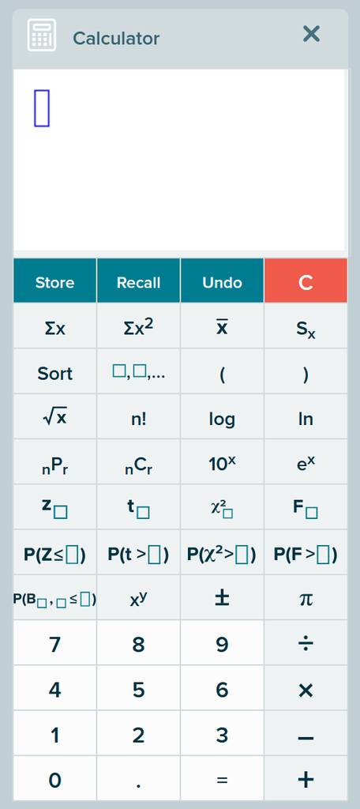

$\sum x$: Add all numeric data values (total).

- For example, 2 + 3 + 7 + 1 = 13
- In ALEKS: sum(2, 3, 7, 1)

$\sum x^2$: Add the square of all numeric data values.

- For example, $2^2 + 3^2 + 7^2 + 1^2 = 63$
- In ALEKS: sumsq(2, 3, 7, 1)

$\bar{X}$: Compute the sample mean. $\bar{X}$ is read as **X-bar**.

- For example, (2 + 3 + 7 + 1)/4 = 3.25
- In ALEKS, mean(2, 3, 7, 1)
- $\bar{X} = \frac{1}{n}\sum x$
- $\sum x = n \bar{X}$

$S_x$: Compute the sample standard deviation.

- For example, $\sqrt{\frac{(2 - 3.25)^2 + (3 - 3.25)^2 + (7 - 3.25)^2 + (1 - 3.25)^2}{4 - 1}} = 2.6299556397$
- In ALEKS, stdev(2, 3, 7, 1)
- S = $\sqrt{S^2}$
- $S^2$ is known as the *sample* variance.
- By definition, $S^2$ = $\frac{1}{n - 1}\sum(x_i - \bar{X})^2$
- $\sum(x_i - \bar{X})^2$ = $(n - 1)S^2$
- There is also the **population variance**, $\sigma^2$. The $\sigma$ is read as **sigma**.
- By definition, $\sigma^2$ = $\frac{1}{n}\sum(x_i - \bar{X})^2$ = $\frac{n - 1}{n}S^2$
- Before using these formulas, check if your data set represents a **sample** or **population**.

**Sort**: Sort numeric data values in ascending order.

- For example, order 2, 3, 7, 1 to 1, 2, 3, 7

[],[],…: Add blank spaces to enter data values.

**(**: Open parenthesis. Useful when combining mathematical operations of defining data set.

**)**: Close parenthesis. Useful when combining mathematical operations of defining data set.

$\sqrt{x}$: Compute the square root of a non-negative number.

- For example, $\sqrt{9}$ = 3

**n!**: Compute the factorial of a whole number.

- For example, 5! = 120
- 5! is read as **5 factorial**. 5! = 1 x 2 x 3 x 4 x 5

**log**: Compute the logarithm in base 10 of a number greater than 0.

- For example, log(3) = 0.47712125472

**ln**: Compute the natural logarithm of a number greater than 0.

- For example, ln(3) = 1.0986122887

$_nP_r$: Compute a permutation. Total number of “ordered” selections of **r** units from **n**.

- For example, $_5P_2$ = $\frac{5!}{(5 - 2)!}$ = 20

$_nC_r$: Compute the combination. Total number of selections of **r** units from **n**. The order is NOT important. The symbol $_nC_r$ is read as “n choose r”.

- For example, $_5C_2$ = $\frac{5!}{2!(5 - 2)!}$ = 10

$10^x$: Compute 10 to the x power.

- For example, $10^3$ = 1000

$e^x$: Compute e to the x power.

- For example, $e^3$ = 20.085536923

**Z**: Compute the Z value corresponding to the right tail area in the Standard Normal Distribution.

- For example, $Z_{0.025}$ = 1.9599639822

**t**: Compute the T value corresponding to the right tail area in the T Distribution with k degrees of freedom.

- For example, $t_{0.025, df=8}$ = 2.3060041108

$X^2$: Compute the $X^2$ value corresponding to the right tail area in the Chi-Squared Distribution with k degrees of freedom.

- For example, $X^2_{0.025, df=8}$ = 17.53454614

**F**: Compute the F value corresponding to the right tail area in the F Distribution with k and l degrees of freedom.

- For example, $F_{0.025, df1=8, df2=5}$ = 6.7571720076

**P(Z < [])**: Compute area to the left of a Z value in the Standard Normal Distribution.

- For example, $P(Z \leq 1.5)$ = 0.93319279873

**P(t > [])**: Compute area to the right of a T value in the T Distribution with k degrees of freedom.

- For example, P(T > 1.5, df=8) = 0.086001645976

$P(X^2$ > []): Compute area to the right of a $X^2$ value in the Chi-Squared Distribution with k degrees of freedom.

- For example, $P(X^2 > 10.5, df=8)$ = 0.23166973811

P(F > []): Compute area to the right of a F value in the F Distribution with k and l degrees of freedom.

- For example, P(F > 10.5, df1=8, df2=5) = 0.0095561813

P(B_,_ $\leq$ []): Compute the total probability of values at or below specific number in the binomial distribution with parameters n and p.

- For example, $P(B_{10},_{0.65} \leq 7)$ = 0.73839260862
- $P(B_{10},_{0.65} \leq 7)$ = p(0) + p(1) + p(2) + …. + p(7)

$x^y$: Raise x to the y power.

- For example, $2^5$ = 32

$\pm$: Assign symbol positive of negative to a number.

$\pi$: Pi number, 3.1415926536

# *9/9: CATEGORICAL & QUANTITATIVE DATA*

## Basic Concept

A **variable** is any characteristic whose value may change from one individual or object to another. A variable can be any of two types:

- **Categorical (Qualitative)**: They represent groups, classification, categories or labels. For example, gender, color, zip code, or country.
- **Numeric (Quantitative)**: They quantify any measurement with numbers. For example, height, weight, test scores, number of seats available or temperature.

Almost all numerical (Quantitative) variables have units. However, there are some exceptions. For example, GPA or shoe size do not have units.

- *Quantitative - Discrete* (countable: phone calls, absent students, or broken computers)
- *Quantitative - Continuous* (uncountable: price, earning, or speed).

## Summarizing Categorical Data with Numbers

Categorical variables are summarized in **Frequency Tables**. The frequency table lists the occurrence of each category in the data.

In addition to the frequency, it is important to include in the summary table the **relative frequency** of each category with respect the data size.

*1)* Make a frequency and relative frequency table.

```r
table(chickwts$feed)
```

```
   casein horsebean   linseed  meatmeal   soybean sunflower
       12        10        12        11        14        12
```

- The function **table( )** displays the frequency table. You know “how many” of each category type is in the data.
- How many groups are available in your data?
- Which one is the most common?, the least common?
- Do they have the same or different count?
- Is there any possible explanation for the count distribution?

*2)* Make a relative frequency table *(or table of proportions)*

- First, COPY the frequency table.

```r
tab_copy <- table(chickwts$feed)
```

The function **prop.table( )** display the proportion table of a “table” object.

```r
prop.table(tab_copy)
```

```
   casein horsebean   linseed  meatmeal   soybean sunflower
0.1690141 0.1408451 0.1690141 0.1549296 0.1971831 0.1690141
```

If your sample *(data)* is a good representation of a large “population”, you can estimate that about 14% of chicken are fed with horsebean.

## Graphical Summary of Categorical Data

A graphical representation of the frequency and relative frequency table can be achieved with the **bar plot**.

- Each bar represents a category with height equal to its frequency *(or relative frequency)*.
- All bars must have the same width and color.
- The bar plot must include a title, and axes with appropriate labels.

**Bar plot in R STUDIO**

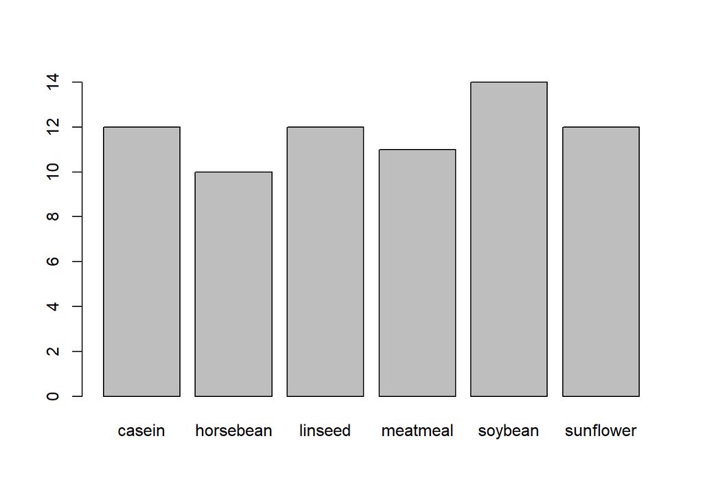

```r
barplot(tab_copy)
```

- The argument between parentheses is a COPY of the frequency table.
- For a relative frequency bar plot, replace with a COPY of the relative frequency table. **(Exercise)**

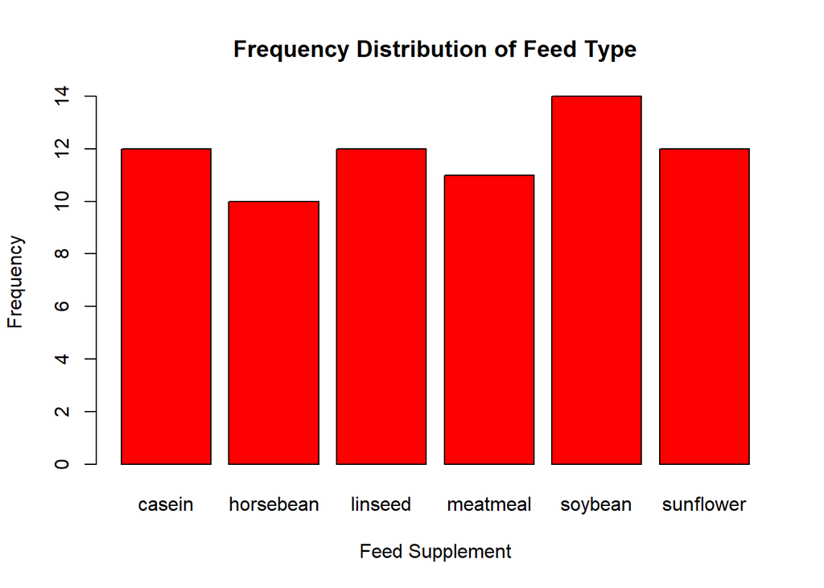

```r
barplot(tab_copy,
        main="Frequency Distribution of Feed Type",
        xlab="Feed Supplement", ylab="Frequency", col="red")
```

## Summarizing Quantitative Data with Numbers

- Quantitative data is best with the five-number summary.
- The five-number summary are the minimum, first quartile, median, third quartile and maximum.
- The median is the number located in the middle of the sorted data. Therefore, half of the data is below the *median* and the other half above.
- The first quartile, *(Q1)*, is a number with one quarter (or 25%) of the data below and 75% above.
- Similarly, the third quartile, *(Q3)*, is a number with three quarter (or 75%) of the data below and 25% above.

In R, the function **summary( )** displays the five-number summary with the mean.

```r
summary(chickwts$weight)
```

```
   Min. 1st Qu.  Median    Mean 3rd Qu.    Max.
  108.0   204.5   258.0   261.3   323.5   423.0
```

What is the weight range in the sample?

What is the weight of the lightest and heavier chicken in the sample?

What is the average weight?

Are the chicken with too small or large weight?

Do the feed supplements help these chicken to growth fast?

## Graphical Summary of Quantitative Data

Plots of quantitative data help to visualize the distribution and unusual observations.

- **Histograms** display the shape of the data distribution *(symmetry, skewness, modes)*.
- Histograms are similar to bar charts. Each bar is a **class intervals** with height equal to the interval’s frequency. *(Frequency histogram)*

In R STUDIO, the function **hist( )** returns a frequency histogram.

- A **Box plot** complements the histogram with the visualization of the five-number summary.
- Box plots are effective for the identification of **outliers** *(unusual observations)*

In R STUDIO, the function **boxplot( )** returns the box plot.

Similar to bar plots, it is important to always display plot title and axes labels in histograms and box plots.

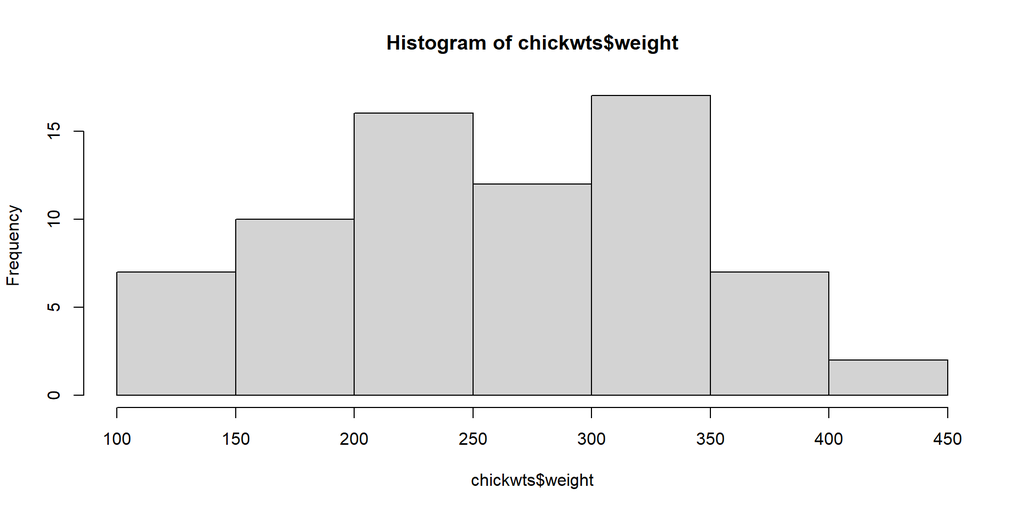

```r
hist(chickwts$weight)
```

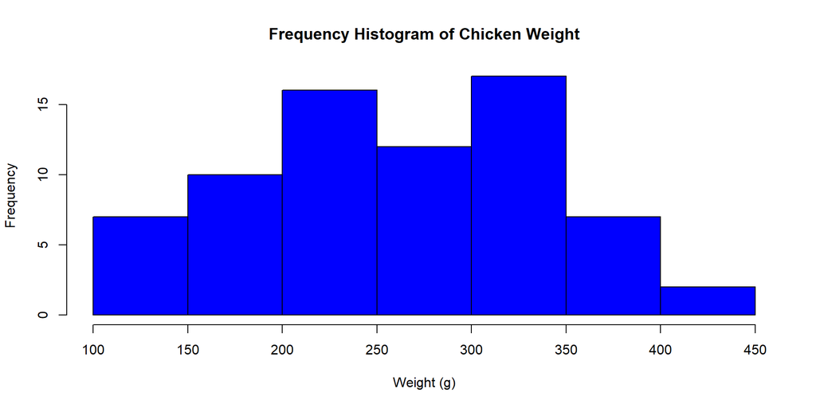

```r
hist(chickwts$weight,
        main="Frequency Histogram of Chicken Weight",
        xlab="Weight (g)", ylab="Frequency", col="blue")
```

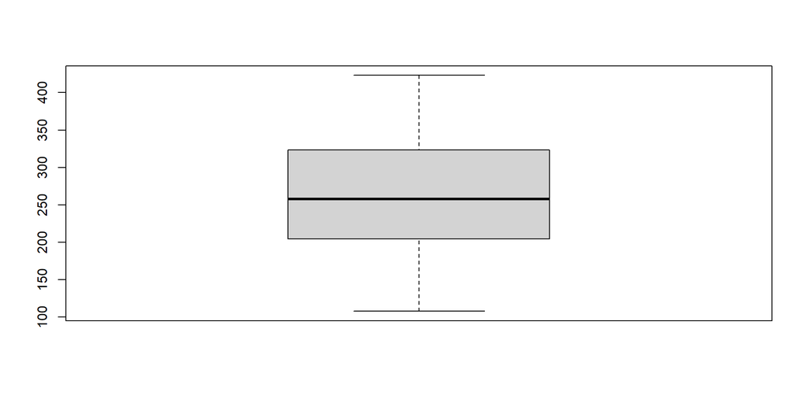

```r
boxplot(chickwts$weight)
```

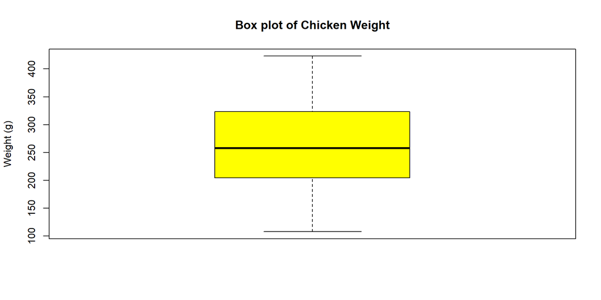

```r
boxplot(chickwts$weight,
        main="Box plot of Chicken Weight",
        xlab=NULL, ylab="Weight (g)", col="yellow")
```

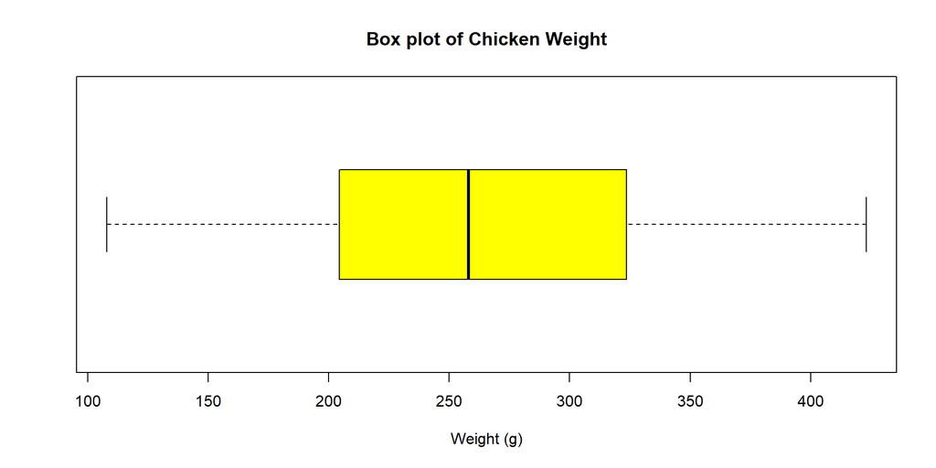

```r
boxplot(chickwts$weight, horizontal = T,
        main="Box plot of Chicken Weight",
        xlab="Weight (g)", ylab=NULL, col="yellow")
```

# *9/12: Introduction to Data Day 1*

Step 1: Open MS Word and R Studio/R script.

Step 2: Prepare your MS Word document.

- Click on the INSERT > Header > Three Column Header
- On each column type: **your name**, **Section 1**, and your instructor name, **A. Falchettore**.
- Save your Word document (FILE > SAVE AS) with the following format: your last name, your first initial, your student ID number, and the letters DD1.
- So, if you are Sue Jones ID 99999999, your document would be saved as **joness99999999DD1**

Step 3: Access Blackboard and read the project instructions **BEFORE** downloading the data file for analysis

## Importing Data to R Studio *(Practice)*

[Click here](https://app.box.com/s/1njhpd3hyvumh4tn9x2yf8tsf1c5z37z) to download the practice data **sleep**. Download file **ONLY**. DO NOT OPEN.

In R Studio, on the top right panel, ENVIRONMENT > **Import Dataset** > From Excel.

Browse *(in Download folder)* your data and import. If you get a warning message to download additional packages, click yes.

**Data Day One:** Today, you are going to do two main things:

- Look at all the variables. Choose *ONE* quantitative and *ONE* categorical variables. Inspect them (*TWO* in total) using R Studio. Describe each one as thoroughly as you can. *(Number of variables in actual Data Day 1 are different)*
- Tell me what question (for each of the chosen variables) you think was asked to result in the answers that were given.

The description for each variable should have this format:

- Name of Variable.
- Question that could have been asked to obtain the responses in this variable.
- Description of tables and charts in layman terms.
- Paste summary tables and charts from R Studio.

## Taking Screenshots of Tables and Charts

- On the keyboard, press simultaneously the keys: **Windows Logo**, **Shift**, **S**.
- Select the area to take the screenshot.
- Paste in MS Word.

## Recommendations (Data Day)

- Read the instructions CAREFULLY. Ask questions if something is not clear.
- Review all lecture notes and use them as reference.
- The key is to describe your results for somebody who does not understand statistics.
- Add title and labels to any chart in your report.
- Save your work OFTEN. Double check if your document was uploaded in BLACKBOARD correctly.
- Be organized and avoid any eventuality like slow computers, internet, or office 365.

# 9/16: Review for Exam 1

## Basic Definitions

- *(Textbook)* A **population** is the entire collection of individuals about which information is sought.
- All possible outcomes in a chance experiment.
- *(Textbook)* A **sample** is a subset of a population, containing the individuals that are actually observed.
- A **simple random sample** of size *n* is a sample chosen by a method in which each collection of *n* population items is equally likely to make up the sample, just as in lottery.

## Understanding Measures of Center or Typical Value (Mean vs Median)

**Sample Mean:** It is denoted with the symbol $\bar{X}$.

- Computation: Add all values $(\sum x_i)$ and divided by the sample size (n).
- Formula: $\bar{X} = \frac{1}{n}\sum x_i$
- The “average” or typical value of your data is measured by the **mean**. The population mean is denoted with the symbol $\mu$ (read as mu). The sample mean is denoted with the symbol $\bar{X}$ (read as X-BAR).

**Median:** By definition, it is a number that splits the data set in half.

- Step 1: Sort the data in ascending order.
- Step 2: If the sample size is ODD, the median is the number in the middle position, else the median is the average of the two middle numbers.

**Flight Time**: The following data represent the flight time (in minutes) of a random sample of seven flights from Las Vegas, Nevada, to Newark, New Jersey, on United Airlines: 282, 270, 260, 266, 257, 260, 277.

Sample Mean: $\bar{X} = \frac{1}{n}\sum X_i$

- $\bar{X} = \frac{1}{7}(282 + 270 + 260 + 266 + 257 + 260 + 277)$
- $\bar{X} = \frac{1}{7}(1872)$ = 267.43

Median = 266

- Sort data: 257 260 260 266 270 277 282
- Since the sample size is odd, 7, Median is the number in $4^{th}$ position, 266

## Mean vs Median vs Mode

| Shape | Relationship | Best Summary of Center |
| --- | --- | --- |
| Bell-Shaped | mean = median = mode | mean |
| Skewed Right | mean > median > mode | median |
| Skewed Left | mean < median < mode | median |

- The **mode** of a variable is the **most frequent** observation in the data set.
- Be careful, the mode is not a measure of central tendency!!!
- The mean (or median) can be interpreted as “typical values” or “averages”. We can also say that half of the data is below (or above) the median.
- The best summary (mean or median) of the center depends on the “shape” of the variable’s distribution.

## Approximating the Mean with Grouped Data

The table below presents the number of text messages sent by a sample of 50 high school students. We will **approximate** the mean number of messages sent.

| Messages sent | Frequency |
| --- | --- |
| 0 - 49 | 10 |
| 50 - 99 | 5 |
| 100 - 149 | 13 |
| 150 - 199 | 11 |
| 200 - 249 | 7 |
| 250 - 299 | 4 |

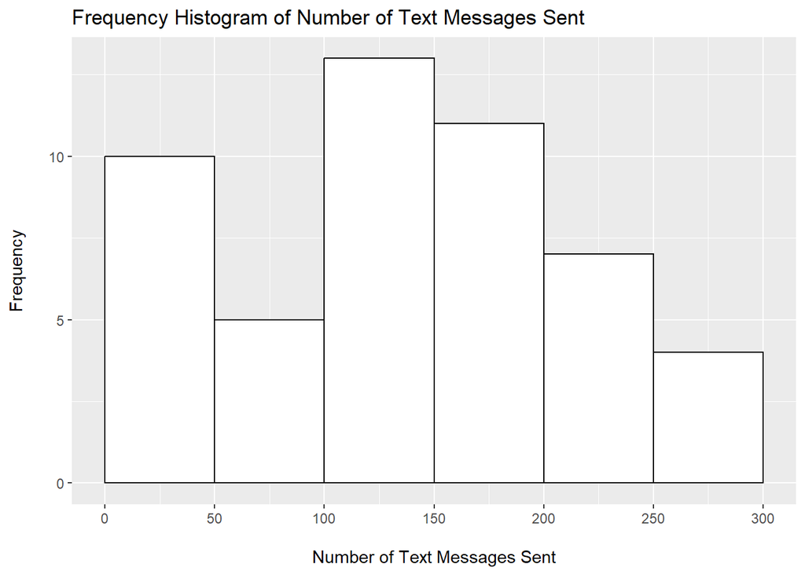

## Procedures for Approximating the Mean with Grouped Data

Step 1: Compute the midpoint of each class.

- The midpoint of a class if found by taking the average of the lower class limit and the lower limit of the next larger class. For the last class, there is no next larger class, but we use the lower limit that the next larger class would have.

| Messages sent | Frequency | Midpoint |
| --- | --- | --- |
| 0 - 49 | 10 | 25 |
| 50 - 99 | 5 | 75 |
| 100 - 149 | 13 | 125 |
| 150 - 199 | 11 | 175 |
| 200 - 249 | 7 | 225 |
| 250 - 299 | 4 | 275 |

Step 2: For each class, multiply the class midpoint by the class frequency.

| Messages sent | Frequency | Midpoint | F x M |
| --- | --- | --- | --- |
| 0 - 49 | 10 | 25 | 250 |
| 50 - 99 | 5 | 75 | 375 |
| 100 - 149 | 13 | 125 | 1625 |
| 150 - 199 | 11 | 175 | 1925 |
| 200 - 249 | 7 | 225 | 1575 |
| 250 - 299 | 4 | 275 | 1100 |

Step 3: Add the products (Midpoint x Frequency) over all classes.

- Total of (F x M) = 250 + 375 + 1625 + 1925 + 1575 + 1100 = **6850**

Step 4: Divide the sum obtained in Step 3 by the sum of the frequencies.

- Mean $\approx$ 6850 / 50 = **137**

## The Weighted Mean

*Definition:* If $x_1, x_2, ...x_n$ are data values, and $w_1, w_2, ..., w_n$ are weights, the **weighted mean** is

- $\bar{X}_w = \frac{w_1x_1 + w_2x_2 + ... + w_nx_n}{w_1 + w_2 + ... + w_n} = \frac{w_ix_i}{w_i}$

Last semester Joe took four courses. He got A is statistics (5 credits), a B in psychology (4 credits), a C in English (3 credits), and an A in music (2 credits). An A is worth 4 quality points, a B is worth 3 points and a C is worth 2 points. Compute Joe’s GPA.

- The data values are the points for each grade: 4, 3, 2, and 4.
- The weights are the number of credits: 5, 4, 3, 2.
- The GPA is the weighted mean: $\frac{5(4) + 4(3) + 3(2) + 2(4)}{5 + 4 + 3 + 2}$
- GPA = **3.29**

## Variability or Spread for NUMERICAL data

**Range:** It is the difference between the maximum and the minimum values in your data.

- Formula: Max - Min

The **sample variance:** It is denoted with the symbol $S^2$.

- Formula: $S^2 = \frac{1}{n - 1}\sum(x_i - \bar{X})^2$

The **sample standard deviation** is the square root of the variance: $S = \sqrt{S^2}$

- Interpret the standard deviation as the average distance of all data values to the mean.

If the population is known, the population variance computed with the formula $\sigma^2 = \frac{1}{n}\sum(x_i - \mu)^2$.

- The population standard deviation is $\sigma$ *(read as sigma)*.

**Flight Time**: The following data represent the flight time (in minutes) of a random sample of seven flights from Las Vegas, Nevada, to Newark, New Jersey, on United Airlines:

282, 270, 260, 266, 257, 260, 267

Compute the spread (or variability) of flight time data.

- It is possible to measure the “spread” of your data with the **range, standard deviation and IQR**.
- By definition, the **range** is the difference between the maximum and minimum data values.
- In this example, **Range** = 282 - 257 = 25 minutes.

Step 1: Before computing the variance, it is necessary to find the mean, $\bar{X}$.

- $\bar{x}$ = $\frac{282 + 270 + 260 + 266 + 257 + 260 + 267}{7}$ = $\frac{1862}{7}$ = 266

Step 2: Compute the difference between the data values and the mean.

| time | $(x_i - \bar{x})$ |
| --- | --- |
| 282 | 16 |
| 270 | 4 |
| 260 | -6 |
| 266 | 0 |
| 257 | -9 |
| 260 | -6 |
| 267 | 1 |

Step 3: Square the differences obtained in column 2

| time | $(x_i - \bar{x})$ | $(x_i - \bar{x})^2$ |
| --- | --- | --- |
| 282 | 16 | 256 |
| 270 | 4 | 16 |
| 260 | -6 | 36 |
| 266 | 0 | 0 |
| 257 | -9 | 81 |
| 260 | -6 | 36 |
| 267 | 1 | 1 |

Step 4: Add the total in column 3

| time | $(x_i - \bar{x})$ | $(x_i - \bar{x})^2$ |
| --- | --- | --- |
| 282 | 16 | 256 |
| 270 | 4 | 16 |
| 260 | -6 | 36 |
| 266 | 0 | 0 |
| 257 | -9 | 81 |
| 260 | -6 | 36 |
| 267 | 1 | 1 |
| **Total** | . | **426** |

Step 5: Get the variance by dividing the total by (n-1) where n is the sample size.

| time | $(x_i - \bar{x})$ | $(x_i - \bar{x})^2$ |
| --- | --- | --- |
| 282 | 16 | 256 |
| 270 | 4 | 16 |
| 260 | -6 | 36 |
| 266 | 0 | 0 |
| 257 | -9 | 81 |
| 260 | -6 | 36 |
| 267 | 1 | 1 |
| **Total** | . | **426** |

- Variance, $S^2$ = $\frac{426}{6}$ = 71 mins $^2$
- Standard Deviation, S = $\sqrt{S^2}$ = $\sqrt{71}$ = 8.426 mins

## Computing the Standard Deviation for Grouped Data.

| Messages sent | Frequency |
| --- | --- |
| 0 - 49 | 10 |
| 50 - 99 | 5 |
| 100 - 149 | 13 |
| 150 - 199 | 11 |
| 200 - 249 | 7 |
| 250 - 299 | 4 |

Find the midpoint of each class and compute the grouped mean like we demonstrated previously.

- Grouped mean = 137

| Messages sent | Frequency | Midpoint | Mean |
| --- | --- | --- | --- |
| 0 - 49 | 10 | 25 | 137 |
| 50 - 99 | 5 | 75 | 137 |
| 100 - 149 | 13 | 125 | 137 |
| 150 - 199 | 11 | 175 | 137 |
| 200 - 249 | 7 | 225 | 137 |
| 250 - 299 | 4 | 275 | 137 |

Compute (midpoint - Mean)

| Messages sent | Frequency | Midpoint | Mean | Md - Mn |
| --- | --- | --- | --- | --- |
| 0 - 49 | 10 | 25 | 137 | -112 |
| 50 - 99 | 5 | 75 | 137 | -62 |
| 100 - 149 | 13 | 125 | 137 | -12 |
| 150 - 199 | 11 | 175 | 137 | 38 |
| 200 - 249 | 7 | 225 | 137 | 88 |
| 250 - 299 | 4 | 275 | 137 | 138 |

*(Md = Midpoint, Mn = Mean)*

Compute $(Md - Mn)^2$ x Frequency

[output not shown]

- Find the total of $(Md - Mn)^2$ x Frequency, 292800.
- Find the total Frequency, 50.
- Compute the variance, $S^2 = \frac{292800}{50 - 1}$ = 5975.5102
- Compute the Standard Deviation, S = $\sqrt{5975.5102}$ = 77.3014